# 1) Introduction: The Crime Analysis task ...*Markdown*, **10 Marks**, Max 300 Words

# Introduction of Crime Analysis Task:

The COVID-19 pandemic devastated the world and left a lasting impact on all facets of life, including life in the United Kingdom. The government imposed unprecedented restrictions on movement and social interaction during multiple periods of lockdown in an effort to stop the virus's spread. In the United Kingdom, the Coronavirus pandemic left an indelible mark on every facet of life (Fancourt et al., 2021). From individual well-being to societal safety, a complex tapestry of consequences unfolded within these hushed streets and shuttered businesses. Legally induced movement restrictions, known as lockdowns, were among the most impactful measures. As a result of this abrupt change, there were concerns about the impact on crime-especially violent and sexual offenses.

## Aim and Objective:

There are four questions that should be answered by the product

- While we primarily focus on violent crime and sexual offences, we acknowledge the interconnectedness of all criminal activity. During that lockdown period, these two categories of crime increased, decreased, or remained stable.
- To create a predictive model based only on lockdown violent crime filtered from all crime data for violent crime and sexual offenses in the UK during the Covid lockdown period of April 2020.
- To calculate the extent to which the observed and expected rates of violent crime differed during the lockdown period.
- Comparing the model-predicted violent crime rates to the actual observed violent crime figures in Leicester during their local lockdown in July 2020 can be accomplished statistically using Timeseries.

## Trend Analysis:

The underlying trend factors in the lockdown period influencing violent crime rates. This information is derived from street-level crime statistics in the United Kingdom. Each of the dataset's 19 million data rows contains a crime type. Using pre-lockdown data, time series analysis and forecasting techniques will be employed to identify trends and seasonality in violent and sexual crime rates.

## Technical Approach:

Utilize Microsoft Azure's Infrastructure as a Service (IaaS) cloud platform to provide scalable computing resources for big data analysis. Our technical approach entailed establishing the infrastructure necessary to access and retrieve data from cloud storage. To handle the large volume of crime data, these platforms provide services such as virtual machines and load balancers. We used PySpark and Pandas to efficiently handle large datasets (Gupta et al.,2020).

# 2) Component Selection and Data Pipeline Implementation *code* **10 Marks**

```python
import warnings
warnings.filterwarnings("ignore")

from pyspark.sql import SparkSession

from pyspark.sql.functions import to_date, col,year ,count,avg,row_number,lit,sum

from pyspark import SparkContext
from pyspark import SparkFiles

from pyspark.ml.feature import VectorAssembler
from pyspark.sql.window import Window
from pyspark.sql.functions import corr
from pyspark.ml.feature import MinMaxScaler
from pyspark.ml.feature import VectorAssembler
from pyspark.sql.types import IntegerType, FloatType
from pyspark.sql.types import *

import matplotlib.pyplot as plt
import numpy as np
import pandas as pd
import seaborn as sns; sns.set_theme()

import statsmodels.api as sm
from statsmodels.tsa.stattools import adfuller
from matplotlib.dates import date2num
from statsmodels.tsa.arima.model import ARIMA
from statsmodels.graphics.tsaplots import plot_acf, plot_pacf
```

```python
spark = SparkSession \
    .builder \
    .appName("My App") \
    .config("spark.some.config.option", "some-value") \
    .getOrCreate()

sc = spark.sparkContext
print(sc.version)
print(sc.appName)
```

```
3.1.2
My App
```

```python
spark.sparkContext.addFile ("https://w21051959.blob.core.windows.net/w21051959/all_crimes21_hdr.txt.gz")
```

```python
all_crimes = spark.read.csv("file:///" + SparkFiles.get("all_crimes21_hdr.txt.gz"), header = True)
```

```python
all_crimes.show(5)
```

```
+--------+-------+--------------------+--------------------+---------+---------+--------------------+---------+--------------------+--------------------+---------------------+-------+
|Crime ID|  Month|         Reported by|        Falls within|Longitude| Latitude|            Location|LSOA code|           LSOA name|          Crime type|Last outcome category|Context|
+--------+-------+--------------------+--------------------+---------+---------+--------------------+---------+--------------------+--------------------+---------------------+-------+
|    null|2010-12|Avon and Somerset...|Avon and Somerset...|-0.805600|51.819143|On or near Norfol...|E01017662| Aylesbury Vale 015C|         Other crime|                 null|   null|
|    null|2010-12|Avon and Somerset...|Avon and Somerset...|-2.494366|51.418169|On or near Keynsh...|E01014399|Bath and North Ea...|Anti-social behav...|                 null|   null|
|    null|2010-12|Avon and Somerset...|Avon and Somerset...|-2.511927|51.409435|On or near Harlec...|E01014399|Bath and North Ea...|Anti-social behav...|                 null|   null|
|    null|2010-12|Avon and Somerset...|Avon and Somerset...|-2.511571|51.414895|On or near Orchar...|E01014399|Bath and North Ea...|Anti-social behav...|                 null|   null|
|    null|2010-12|Avon and Somerset...|Avon and Somerset...|-2.511927|51.409435|On or near Harlec...|E01014399|Bath and North Ea...|Anti-social behav...|                 null|   null|
+--------+-------+--------------------+--------------------+---------+---------+--------------------+---------+--------------------+--------------------+---------------------+-------+
only showing top 5 rows
```

```python
all_crimes.columns
```

```
['Crime ID',
 'Month',
 'Reported by',
 'Falls within',
 'Longitude',
 'Latitude',
 'Location',
 'LSOA code',
 'LSOA name',
 'Crime type',
 'Last outcome category',
 'Context']
```

```python
all_crimes.select('Crime type').distinct().show()
```

```
+--------------------+
|          Crime type|
+--------------------+
|       Bicycle theft|
|        Public order|
|               Drugs|
|Public disorder a...|
|         Other crime|
|             Robbery|
|Criminal damage a...|
|Theft from the pe...|
|         Shoplifting|
|            Burglary|
|       Violent crime|
|         Other theft|
|Possession of wea...|
|Violence and sexu...|
|       Vehicle crime|
|Anti-social behav...|
+--------------------+
```

```python
violent_crimes_df = all_crimes.filter(
    col('Crime type').isin('Violence and sexual offences', 'Violent crime'))
```

```python
violent_crimes_df.show(5)
```

```
+--------+-------+--------------------+--------------------+---------+---------+--------------------+---------+--------------------+-------------+---------------------+-------+
|Crime ID|  Month|         Reported by|        Falls within|Longitude| Latitude|            Location|LSOA code|           LSOA name|   Crime type|Last outcome category|Context|
+--------+-------+--------------------+--------------------+---------+---------+--------------------+---------+--------------------+-------------+---------------------+-------+
|    null|2010-12|Avon and Somerset...|Avon and Somerset...|-2.509773|51.405767|On or near Cedar ...|E01014402|Bath and North Ea...|Violent crime|                 null|   null|
|    null|2010-12|Avon and Somerset...|Avon and Somerset...|-2.497371|51.412906|On or near Temple...|E01014403|Bath and North Ea...|Violent crime|                 null|   null|
|    null|2010-12|Avon and Somerset...|Avon and Somerset...|-2.503260|51.410965|On or near Courtl...|E01014403|Bath and North Ea...|Violent crime|                 null|   null|
|    null|2010-12|Avon and Somerset...|Avon and Somerset...|-2.498987|51.406757|On or near Tamwor...|E01014404|Bath and North Ea...|Violent crime|                 null|   null|
|    null|2010-12|Avon and Somerset...|Avon and Somerset...|-2.483216|51.416346|On or near Broadm...|E01014396|Bath and North Ea...|Violent crime|                 null|   null|
+--------+-------+--------------------+--------------------+---------+---------+--------------------+---------+--------------------+-------------+---------------------+-------+
only showing top 5 rows
```

# 3) Data Extraction and Filtering ... *code*, 10 Marks

```python
violent_crimes_df.select('Crime type').distinct().show()
```

```
+--------------------+
|          Crime type|
+--------------------+
|       Violent crime|
|Violence and sexu...|
+--------------------+
```

```python
violent_crimes_df = violent_crimes_df.withColumn('Month', to_date(col('Month'), 'yyyy-MM'))
```

```python
violent_crimes_df.select('Month').dtypes[0][1]
```

```
'date'
```

```python
violent_crimes_df = violent_crimes_df.withColumn('Year', year('Month'))
```

```python
violent_crimes_df.count()
```

```
13084759
```

```python
violent_crimes_Before_lockdown = violent_crimes_df.filter( (violent_crimes_df['Month'] <= '2020-04'))

average_crimes_Before_lockdown = violent_crimes_Before_lockdown.groupBy('Month').agg({'Crime ID': 'count'}).withColumnRenamed('count(Crime ID)', 'total_crimes')

average_crimes_Before_lockdown = average_crimes_Before_lockdown.agg(avg('total_crimes').alias('average_total_crimes'))
```

```python
violent_crimes_during_lockdown = violent_crimes_df.filter((violent_crimes_df['Month'] >= '2020-04') | (violent_crimes_df['Month'] <= '2020-12') )

average_crimes_during_lockdown = violent_crimes_during_lockdown.groupBy('Month').agg({'Crime ID': 'count'}).withColumnRenamed('count(Crime ID)', 'total_crimes')

average_crimes_during_lockdown = average_crimes_during_lockdown.agg(avg('total_crimes').alias('average_total_crimes'))
```

```python
average_crimes_Before_lockdown.show()
```

```
+--------------------+
|average_total_crimes|
+--------------------+
|   91019.73451327434|
+--------------------+
```

```python
average_crimes_during_lockdown.show()
```

```
+--------------------+
|average_total_crimes|
+--------------------+
|   97809.47619047618|
+--------------------+
```

# 4) Design, Development and reasoning behind use of multiple visualization methods, statistics, and machine learning Models, *markdown*, *code*, *markdown*, 20 Marks

ARIMA (Autoregressive Integrated Moving Average) models provide a popular statistical framework for analyzing and forecasting time series data. The autoregressive (AR) component uses a regression equation incorporating past lags of the time series to predict future values. The integrated (I) component handles non-stationary raw data by differencing it before model fitting. The moving average (MA) part utilizes past forecast errors as lagged predictors in the regression. Together, the AR and MA elements account for inherent autocorrelations in temporal data. By optimizing the ARIMA parameters p, d, and q, the model fit can be tuned. Any trends, seasonalities, and cycles are uncovered to understand the dynamics and make data-driven forecasts. The flexible yet robust ARIMA approach is widely applied because it leverages autocorrelation structures and insights from the time series itself using lags of values and errors to predict ahead. This makes ARIMA a staple technique for time series analysis across domains (Sarkar et al., 2020).

```python
violent_crimes_monthly = violent_crimes_df.groupBy('Month').agg({'Crime ID': 'count'}).withColumnRenamed('count(Crime ID)', 'total_crimes')
```

```python
violent_crimes_monthly_pandas = violent_crimes_monthly.toPandas()
```

```python
violent_crimes_monthly_pandas
```

|  | Month | total_crimes |
| --- | --- | --- |
| 0 | 2016-03-01 | 98294 |
| 1 | 2019-11-01 | 151484 |
| 2 | 2014-08-01 | 70695 |
| 3 | 2018-09-01 | 150082 |
| 4 | 2010-12-01 | 1067 |
| ... | ... | ... |
| 121 | 2013-06-01 | 57248 |
| 122 | 2012-11-01 | 53848 |
| 123 | 2020-06-01 | 158275 |
| 124 | 2019-06-01 | 164998 |
| 125 | 2018-06-01 | 155050 |

126 rows × 2 columns

```python
violent_crimes_monthly_pandas['Month'] = pd.to_datetime(violent_crimes_monthly_pandas['Month'])
```

```python
violent_crimes_monthly_pandas.set_index('Month', inplace=True)
```

```python
violent_crimes_monthly_pandas.sort_index(inplace=True)
```

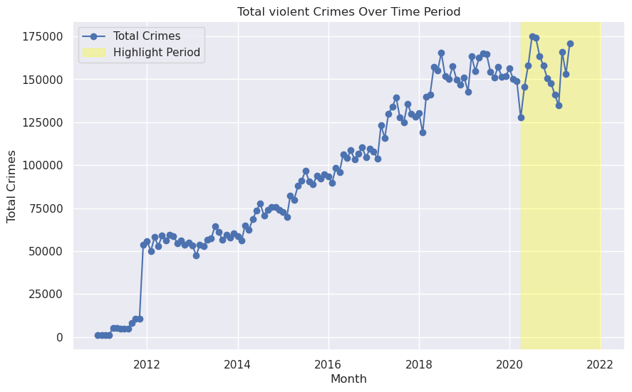

```python
plt.figure(figsize=(10, 6))
plt.plot(violent_crimes_monthly_pandas.index, violent_crimes_monthly_pandas['total_crimes'], marker='o', linestyle='-', label='Total Crimes')

highlight_start = pd.to_datetime('2020-04-01')
highlight_end = pd.to_datetime('2021-12-31')
plt.axvspan(date2num(highlight_start), date2num(highlight_end), color='yellow', alpha=0.3, label='Highlight Period')

plt.title('Total violent Crimes Over Time Period')
plt.xlabel('Month')
plt.ylabel('Total Crimes')
plt.grid(True)
plt.legend()
plt.show()
```

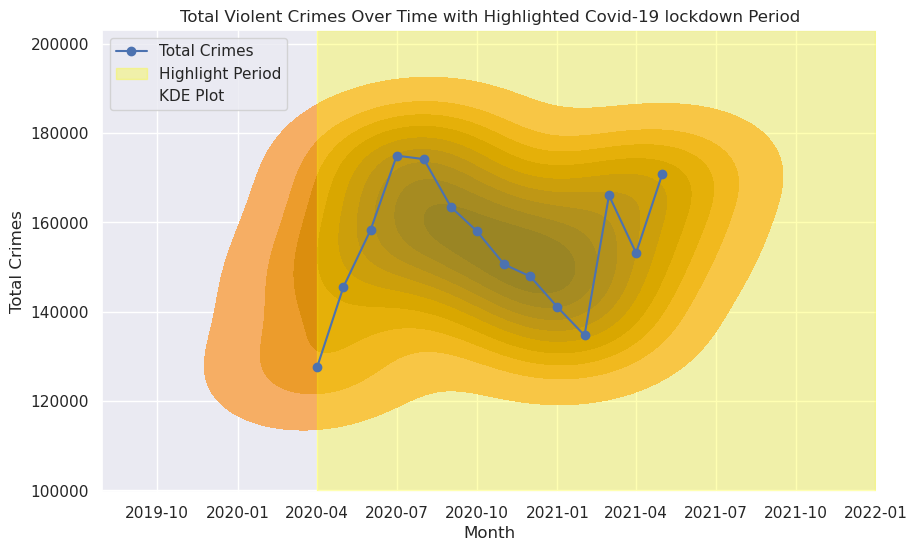

```python
plt.figure(figsize=(10, 6))

filtered_data = violent_crimes_monthly_pandas.loc['2020-04-01':'2021-12-31']

plt.plot(filtered_data.index, filtered_data['total_crimes'], marker='o', linestyle='-', label='Total Crimes')

highlight_start = pd.to_datetime('2020-04-01')
highlight_end = pd.to_datetime('2021-12-31')

plt.axvspan(date2num(highlight_start), date2num(highlight_end), color='yellow', alpha=0.3, label='Highlight Period')

sns.kdeplot(filtered_data.index, filtered_data['total_crimes'], fill=True, label='KDE Plot', color='orange')
plt.title('Total Violent Crimes Over Time with Highlighted Covid-19 lockdown Period')
plt.xlabel('Month')
plt.ylabel('Total Crimes')
plt.grid(True)
plt.legend()
plt.show()
```

```python
violent_crimes_yearly = violent_crimes_df.groupBy('Year').agg({'Crime ID': 'count'}).withColumnRenamed('count(Crime ID)', 'total_crimes')
```

```python
violent_crimes_yearly.show()
```

```
+----+------------+
|Year|total_crimes|
+----+------------+
|2018|     1764153|
|2015|     1040969|
|2013|      680559|
|2014|      831852|
|2019|     1870222|
|2020|     1855750|
|2012|      670061|
|2016|     1231351|
|2010|        1067|
|2011|      111285|
|2017|     1500906|
|2021|      765819|
+----+------------+
```

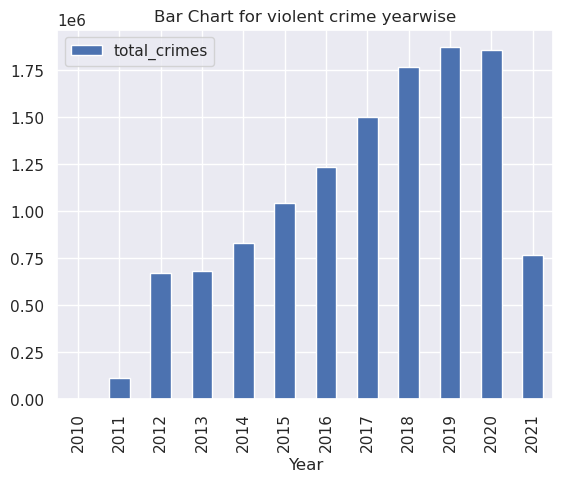

```python
violent_crimes_pandas = violent_crimes_yearly.toPandas()

violent_crimes_pandas = violent_crimes_pandas.sort_values(by='Year')

violent_crimes_pandas.plot(x='Year', y='total_crimes', kind='bar')
plt.title('Bar Chart for violent crime yearwise')
plt.show()
```

```python
violent_crimes_df_crime_count = violent_crimes_df.groupBy('Month').agg(count('*').alias('CrimeCount'))
```

```python
violent_crimes_df_crime_count.count()
```

```
126
```

```python
violent_crimes_pandas = violent_crimes_df_crime_count.toPandas()
```

```python
violent_crimes_pandas
```

|  | Month | CrimeCount |
| --- | --- | --- |
| 0 | 2016-03-01 | 98294 |
| 1 | 2019-11-01 | 152923 |
| 2 | 2014-08-01 | 71341 |
| 3 | 2018-09-01 | 151099 |
| 4 | 2010-12-01 | 57580 |
| ... | ... | ... |
| 121 | 2013-06-01 | 57815 |
| 122 | 2012-11-01 | 54424 |
| 123 | 2020-06-01 | 158701 |
| 124 | 2019-06-01 | 166106 |
| 125 | 2018-06-01 | 156092 |

126 rows × 2 columns

```python
violent_crimes_pandas.Month = violent_crimes_pandas.Month.astype('datetime64[ns]')
violent_crimes_pandas = violent_crimes_pandas.set_index(pd.to_datetime(violent_crimes_pandas.Month))
```

```python
violent_crimes_pandas.index
```

```
DatetimeIndex(['2016-03-01', '2019-11-01', '2014-08-01', '2018-09-01',
               '2010-12-01', '2018-11-01', '2015-04-01', '2012-09-01',
               '2015-08-01', '2016-01-01',
               ...
               '2017-05-01', '2011-08-01', '2014-01-01', '2014-12-01',
               '2017-04-01', '2013-06-01', '2012-11-01', '2020-06-01',
               '2019-06-01', '2018-06-01'],
              dtype='datetime64[ns]', name='Month', length=126, freq=None)
```

```python
violent_crimes_pandas = violent_crimes_pandas.sort_index()
```

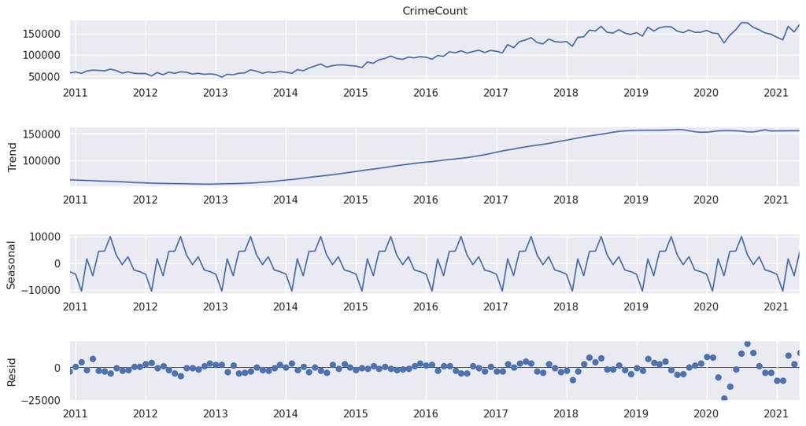

```python
decomposition = sm.tsa.seasonal_decompose(violent_crimes_pandas['CrimeCount'], model='additive',extrapolate_trend='freq')
fig = decomposition.plot()
fig.set_size_inches(14,7)
plt.show()
```

### Function to Test Stationarity and Visualize Time Series Characteristics

```python
def test_stationarity(timeseries, title):
    plt.clf()
    rolmean = pd.Series(timeseries).rolling(window=12).mean()
    rolstd = pd.Series(timeseries).rolling(window=12).std()

    fig, ax = plt.subplots(figsize=(16, 4))
    ax.plot(timeseries, label= title)
    ax.plot(rolmean, label='rolling mean');
    ax.plot(rolstd, label='rolling std (x10)');
    ax.legend()
    plt.show()
```

### Augmented Dickey-Fuller Test Function

```python
def ADF_test(timeseries, dataDesc):
    print(' > Is the {} stationary ?'.format(dataDesc))
    dftest = adfuller(timeseries.dropna(), autolag='AIC')
    print('Test statistic = {:.3f}'.format(dftest[0]))
    print('P-value = {:.3f}'.format(dftest[1]))
    print('Critical values :')
    for k, v in dftest[4].items():
        print('\t{}: {} - The data is {} stationary with {}% confidence'.format(k, v, 'not' if v<dftest[0] else '', 100-int(k[:-1])))
```

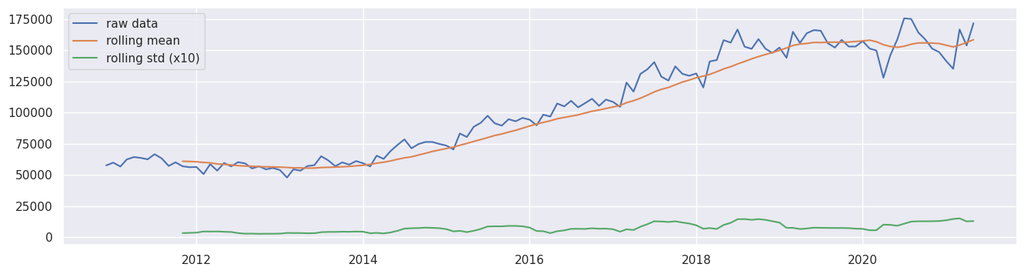

```python
pd.options.display.float_format = '{:.8f}'.format
test_stationarity(violent_crimes_pandas['CrimeCount'],'raw data')
```

```python
ADF_test(violent_crimes_pandas['CrimeCount'],'raw data')
```

```
 > Is the raw data stationary ?
Test statistic = -0.305
P-value = 0.925
Critical values :
	1%: -3.489589552580676 - The data is not stationary with 99% confidence
	5%: -2.887477210140433 - The data is not stationary with 95% confidence
	10%: -2.580604145195395 - The data is not stationary with 90% confidence
```

```python
shift_size = 3
```

### Detrending

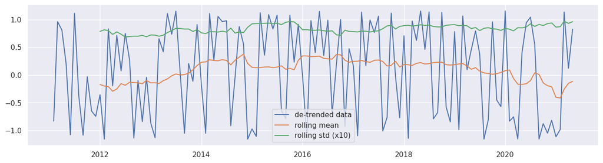

```
 > Is the de-trended data stationary ?
Test statistic = -1.610
P-value = 0.479
Critical values :
	1%: -3.4912451337340342 - The data is not stationary with 99% confidence
	5%: -2.8881954545454547 - The data is not stationary with 95% confidence
	10%: -2.5809876033057852 - The data is not stationary with 90% confidence
```

```python
y = violent_crimes_pandas['CrimeCount']
y_detrend =  (y - y.rolling(window=shift_size).mean())/y.rolling(window=shift_size).std()

test_stationarity(y_detrend,'de-trended data')
ADF_test(y_detrend,'de-trended data')
```

### Differencing

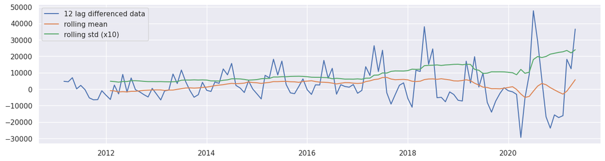

```
 > Is the 12 lag differenced data stationary ?
Test statistic = -1.919
P-value = 0.323
Critical values :
	1%: -3.49181775886872 - The data is not stationary with 99% confidence
	5%: -2.8884437992971588 - The data is not stationary with 95% confidence
	10%: -2.5811201893779985 - The data is not stationary with 90% confidence
```

```python
y_12lag =  y - y.shift(shift_size)

test_stationarity(y_12lag,'12 lag differenced data')
ADF_test(y_12lag,'12 lag differenced data')
```

### Detrending + Differencing

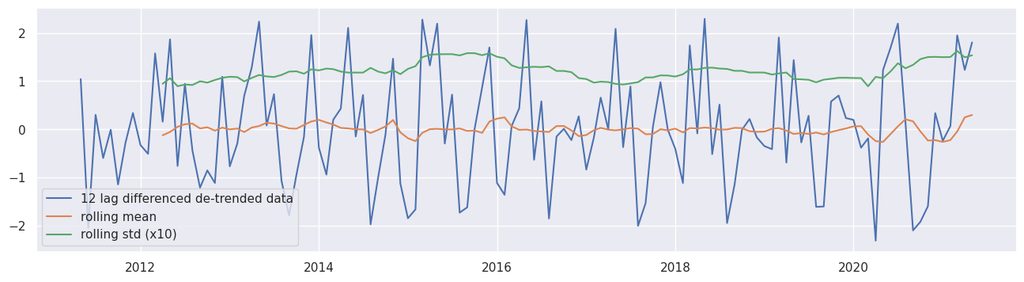

```
 > Is the 12 lag differenced de-trended data stationary ?
Test statistic = -7.003
P-value = 0.000
Critical values :
	1%: -3.4912451337340342 - The data is  stationary with 99% confidence
	5%: -2.8881954545454547 - The data is  stationary with 95% confidence
	10%: -2.5809876033057852 - The data is  stationary with 90% confidence
```

```python
y_12lag_detrend =  y_detrend - y_detrend.shift(shift_size)

test_stationarity(y_12lag_detrend,'12 lag differenced de-trended data')

ADF_test(y_12lag_detrend,'12 lag differenced de-trended data')
```

```python
y_12lag_detrend
```

```
Month
2010-12-01           NaN
2011-01-01           NaN
2011-02-01           NaN
2011-03-01           NaN
2011-04-01           NaN
                 ...
2021-01-01   -0.23605959
2021-02-01    0.06740174
2021-03-01    1.95028725
2021-04-01    1.23406172
2021-05-01    1.80466144
Name: CrimeCount, Length: 126, dtype: float64
```

Time series techniques like ADF tests, rolling statistics, and stationarity testing make assumptions about the data structure that may not hold. Factors like variance and lag may not follow expected patterns, which could undermine the utility of stationarity metrics derived from these techniques

# 5) Selection, application, and reasoning behind use of statistical analysis and multiple evaluation measures *markdown*, *code*, *markdown*, 20 Marks

As a result, we can extract the subset of data that is required to examine the various visualization techniques, such as line charts, bar charts, and decomposition plots. The data collected during and before COVID-19 lockdown periods can be used to analyze the seasonal, residual, and trend aspects of these violent crimes. There are many different kinds of crimes included in the total crime data that is collected (Piquero et al., 2021), and then only violent and sexual offenses are selected. With this filtered information, we can then count the number of violent and sexual crimes and find the average during the COVID lockdown period to compare with the before lockdown period that occurred within each year and month to generate a dataset that displays the frequency of these offenses over time throughout the lockdowns.

```python
crime_count_before_april_2020_pd = y_12lag_detrend[y_12lag_detrend.index < '2020-04-01']
```

```python
order = (1, 1, 1)
arima_model = ARIMA(crime_count_before_april_2020_pd, order=order)
arima_result = arima_model.fit()
```

```python
predicted_values = arima_result.predict(start=len(crime_count_before_april_2020_pd), end=len(crime_count_before_april_2020_pd), typ='levels')
```

```python
predicted_values
```

```
2020-04-01   -0.33867182
Freq: MS, dtype: float64
```

```python
y_12lag_detrend[y_12lag_detrend.index == '2020-04-01']
```

```
Month
2020-04-01   -2.30748252
Name: CrimeCount, dtype: float64
```

```python
y_true, y_pred = y_12lag_detrend[y_12lag_detrend.index == '2020-04-01'][0],predicted_values[0]
```

```python
ae = abs(y_true - y_pred)
se = (y_true - y_pred)**2
percentage_error = ((y_true - y_pred) / abs(y_true)) * 100

print(f'Absolute Error: {ae}')
print(f'Squared Error: {se}')
```

```
Absolute Error: 1.9688107032574114
Squared Error: 3.8762155852609426
```

```python
filtered_leicester_df = violent_crimes_df.filter(col('LSOA name').like('%Leicester%'))
```

```python
filtered_leicester_df.count()
```

```
119898
```

```python
filtered_leicester_df.filter((filtered_leicester_df['Month'] == '2020-07')).count()
```

```
1726
```

```python
filtered_leicester_df.filter((filtered_leicester_df['Month'] >= '2020-07') | (filtered_leicester_df['Month'] <= '2021-12')).count()
```

```
119898
```

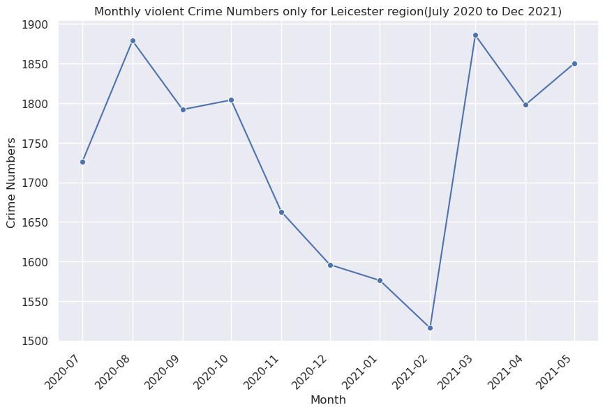

```python
filtered_df = filtered_leicester_df.filter(
    (filtered_leicester_df['Month'] >= '2020-07') & (filtered_leicester_df['Month'] <= '2021-12') &
    (filtered_leicester_df['Crime type'].isin('Violence and sexual offences', 'Violent crime'))
)


monthly_counts = (
    filtered_df.groupBy('Month')
               .agg(count('Crime type').alias('CrimeNumbers'))
               .orderBy('Month')
)

monthly_counts_pandas = monthly_counts.toPandas()


plt.figure(figsize=(10, 6))
sns.lineplot(x='Month', y='CrimeNumbers', data=monthly_counts_pandas, marker='o')
plt.xlabel('Month')
plt.ylabel('Crime Numbers')
plt.title('Monthly violent Crime Numbers only for Leicester region(July 2020 to Dec 2021)')
plt.xticks(rotation=45, ha='right')
plt.show()
```

# 6) Detailed Analysis and consideration of the appropriateness of the solution for the initial problem *markdown*, 10 Marks

# Advantages

### Data Scalability and storage

The integration of big data and cloud computing yields a scalable infrastructure solution suitable for handling extensive data analytics. Vast information resources become easily accessible by utilizing the cloud's on-demand computing power, analytics capabilities, and storage. This makes it possible to extract meaningful knowledge from big data that has numerous applications in daily life (Islam et al., 2019).

### Elasticity

The ability to elastically scale computing, storage, and network capabilities upward or downward on demand is a major advantage of cloud computing. The cloud's infrastructure enables flexible expansion of compute and storage capacity to handle new data inflows for big data analytics. The storage service in the cloud can dynamically allocate more resources to provide the necessary capacity as more criminal activity incident records become available over time (Yang et al., 2017).

### Data Privacy and Security

Sensitive crime data can be better secured by implementing strong physical and virtual security measures like access controls, encryption, and threat detection, thanks to the cloud's economies of scale. Because of the adaptability of cloud infrastructure, strong privacy enhancements are supported, such as anonymization and fine-grained access controls that safeguard identities while obtaining insights. Governance procedures also ingrain ethical behavior regarding access to private information (Y. K. Gupta et al., 2020). Cloud-based big data solutions can enable crime analysis and enhance security and privacy safeguards with careful implementation.

# Disadvantages

Encryption is vital but can be inefficient with massive data volumes. Compressing big data to remove redundancy helps prior to encrypting. However, traditional compression techniques have limitations for large, complex data sets. New optimized compression algorithms are needed that reduce data volume to enable efficient encryption while still allowing effective queries and analytics on the encrypted data. The redundancy removal must balance security, query performance, and overhead (Y. Hui and L. Zesong, 2019). Big data presents challenges in ensuring data quality's four components - consistency, redundancy, completeness, and accuracy. Sharing big data widely with frequent changes exacerbates difficulties maintaining data consistency and integrity (Mohamed et al., 2020).

# Limitations

While big data can help reduce risk and costs and improve making decisions, it also poses certain legal issues. These techniques need to be in line with data protection laws and principles, particularly when processing personal data for Big Data applications. These ideas require additional consideration and improvement in light of technological advancements (Forgó et al., 2017). One particularly difficult concept in that regard is the fundamental idea of "purpose limitation". Integrating big data with the cloud has advantages but also poses security risks. Companies must implement robust security measures to protect sensitive data and prevent breaches in the cloud environment. While beneficial, moving big data to the cloud comes with potential loss of control, lock-in, and a lack of customization. Organizations should carefully weigh the pros and cons before deployment. With proper precautions, the cloud can securely harness big data (El-Seoud et al., 2017).

## Challenges

The technological infrastructure needed to store and process large amounts of detailed crime data is a significant barrier. The scalability of traditional data warehouses is insufficient to manage big data analytics. Businesses need to spend money building data lakes on cloud platforms in order to combine unstructured and structured data. On the other hand, keeping unprocessed crime data on the cloud may cause privacy issues (Porcedda, M.G. and Wall, D.S., 2018).The Velocity, Volume and Variety of big data create security and privacy challenges. Rapid data generation, massive scale, and heterogeneous sources make safeguarding information difficult. Cloud infrastructure, streaming data, and inter-cloud transfers present variables to address. Strong encryption, access control, and governance are needed to protect privacy, avoid breaches and mitigate threats. Proper security is essential to utilize big data analytics while minimizing risksc(Khan, M. and Ansari, M.D., 2019).

There are difficulties in operating flexible cloud infrastructure to handle different types of workloads. The majority of companies lack the deep technical expertise needed for cloud service performance tuning and cost optimizing. Costs associated with ad hoc exploratory analytics on large datasets can rise quickly. Although they are helpful, abstracted cloud-based services offer less insight into how resources are being used (Yang et al., 2017).